# CS 422 HW8

Sesha Shai Datta Kolli, Illinois Institute of Technology

```r
setwd("D:/Masters/DM/HW7/")
library(Hmisc)
```

### Part 2.1-A-i

| Name | I | i | C | c | P | p | M | m |
| --- | --- | --- | --- | --- | --- | --- | --- | --- |
| Opossum | 5 | 4 | 1 | 1 | 3 | 3 | 4 | 4 |
| Hairy tail mole | 3 | 3 | 1 | 1 | 4 | 4 | 3 | 3 |
| Common mole | 3 | 2 | 1 | 0 | 3 | 3 | 3 | 3 |
| Star nose mole | 3 | 3 | 1 | 1 | 4 | 4 | 3 | 3 |
| Brown bat | 2 | 3 | 1 | 1 | 3 | 3 | 3 | 3 |
| Silver hair bat | 2 | 3 | 1 | 1 | 2 | 3 | 3 | 3 |
| Pigmy bat | 2 | 3 | 1 | 1 | 2 | 2 | 3 | 3 |
| House bat | 2 | 3 | 1 | 1 | 1 | 2 | 3 | 3 |
| Red bat | 1 | 3 | 1 | 1 | 2 | 2 | 3 | 3 |
| Hoary bat | 1 | 3 | 1 | 1 | 2 | 2 | 3 | 3 |

[output cut: 56 more lines]

We can remove the Name attribute from the data. The name of the each mammal is unique,that offers no assistance for performing clustering

### Part 2.1-A-ii

```r
summary(df)
```

```
     Name                 I               i               C                c                P               p               M
 Length:66          Min.   :0.000   Min.   :0.000   Min.   :0.0000   Min.   :0.0000   Min.   :0.000   Min.   :0.000   Min.   :0.000
 Class :character   1st Qu.:1.000   1st Qu.:1.000   1st Qu.:0.0000   1st Qu.:0.0000   1st Qu.:2.000   1st Qu.:1.000   1st Qu.:1.000
 Mode  :character   Median :2.000   Median :3.000   Median :1.0000   Median :1.0000   Median :3.000   Median :3.000   Median :3.000
                    Mean   :1.803   Mean   :2.379   Mean   :0.5909   Mean   :0.5455   Mean   :2.561   Mean   :2.424   Mean   :2.455
                    3rd Qu.:3.000   3rd Qu.:3.000   3rd Qu.:1.0000   3rd Qu.:1.0000   3rd Qu.:3.000   3rd Qu.:3.000   3rd Qu.:3.000
                    Max.   :5.000   Max.   :4.000   Max.   :1.0000   Max.   :1.0000   Max.   :4.000   Max.   :4.000   Max.   :8.000
       m
 Min.   :0.000
 1st Qu.:2.000
 Median :3.000
 Mean   :2.636
 3rd Qu.:3.000
 Max.   :8.000
```

```r
cat("\nThe Standard-deviation of I is :",sd(df$I),"\n")
```

```
The Standard-deviation of I is : 1.192537
```

```r
cat("The Standard-deviation of i is :",sd(df$i),"\n")
```

```
The Standard-deviation of i is : 1.16044
```

```r
cat("\nThe Standard-deviation of C is :",sd(df$C),"\n")
```

```
The Standard-deviation of C is : 0.4954337
```

```r
cat("The Standard-deviation of c is :",sd(df$c),"\n")
```

```
The Standard-deviation of c is : 0.5017452
```

```r
cat("\nThe Standard-deviation of p is :",sd(df$p),"\n")
```

```
The Standard-deviation of p is : 1.265648
```

```r
cat("The Standard-deviation of P is :",sd(df$P),"\n")
```

```
The Standard-deviation of P is : 1.216917
```

```r
cat("\nThe Standard-deviation of M is :",sd(df$M),"\n")
```

```
The Standard-deviation of M is : 1.16595
```

```r
cat("The Standard-deviation of m is :",sd(df$m),"\n")
```

```
The Standard-deviation of m is : 1.017332
```

### Part 2.1-A-iii

```r
df1<- subset(df, select = -c(Name))
data<-as.data.frame(apply(df1,2,function(x)gsub('\\s+', '',x)))
head(data)
```

|  | I | i | C | c | P | p | M | m |
| --- | --- | --- | --- | --- | --- | --- | --- | --- |
| 1 | 5 | 4 | 1 | 1 | 3 | 3 | 4 | 4 |
| 2 | 3 | 3 | 1 | 1 | 4 | 4 | 3 | 3 |
| 3 | 3 | 2 | 1 | 0 | 3 | 3 | 3 | 3 |
| 4 | 3 | 3 | 1 | 1 | 4 | 4 | 3 | 3 |
| 5 | 2 | 3 | 1 | 1 | 3 | 3 | 3 | 3 |
| 6 | 2 | 3 | 1 | 1 | 2 | 3 | 3 | 3 |

```r
write.table(data, file = "data.txt", sep = " ",
            row.names = TRUE, col.names = NA)
```

### Part 2.1-B-i

```r
df1<- subset(df, select = -c(Name))
pkgs <- c("factoextra",  "NbClust")
install.packages(pkgs)
```

[output not shown]

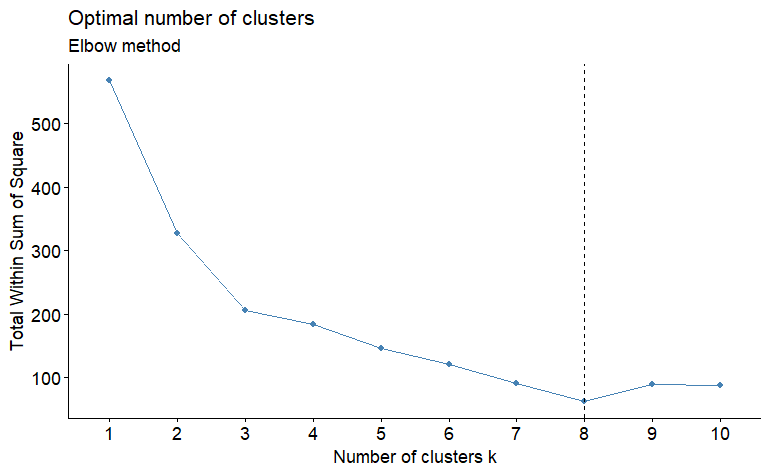

```r
library(factoextra)
library(NbClust)
library("fpc")
fviz_nbclust(df1, kmeans, method = "wss")+
    geom_vline(xintercept = 8, linetype = 2)+
  labs(subtitle = "Elbow method")
```

### Part 2-2.1-b-ii

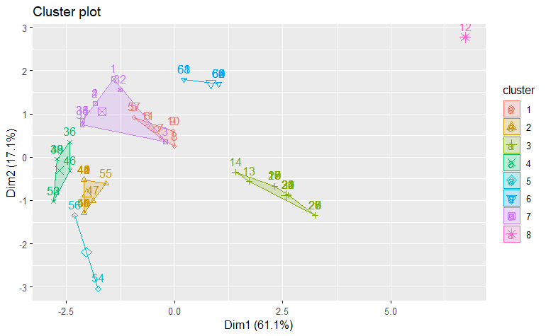

```r
k2 <- kmeans(df1, centers =8)
fviz_cluster(k2, data = df1)
```

### Part 2-2.1-b-iii

```r
cat("The Number of observation in each cluster\n")
```

```
The Number of observation in each cluster
```

```r
for (x in 1:8) {
  cat("The size of the ",x,"cluster is",k2$size[x],"\n")
}
```

```
The size of the  1 cluster is 8
The size of the  2 cluster is 11
The size of the  3 cluster is 19
The size of the  4 cluster is 7
The size of the  5 cluster is 2
The size of the  6 cluster is 9
The size of the  7 cluster is 9
The size of the  8 cluster is 1
```

### Part 2-2.1-b-iv

```r
cat("The Total SSE of the cluster is:",k2$tot.withinss)
```

```
The Total SSE of the cluster is: 66.16759
```

### Part 2-2.1-b-v

```r
for (x in 1:8) {
  cat("The size of the ",x,"cluster is",k2$withinss[x],"\n")
}
```

```
The size of the  1 cluster is 6.375
The size of the  2 cluster is 7.636364
The size of the  3 cluster is 23.47368
The size of the  4 cluster is 4.571429
The size of the  5 cluster is 3
The size of the  6 cluster is 1.555556
The size of the  7 cluster is 19.55556
The size of the  8 cluster is 0
```

### Part 2-2.1-b-vi

```r
analysis_data<-data.frame(name=character(0),cluster=numeric(0))
for(i in 1:nrow(df)){
  analysis_data[i,1]<-as.character(df[i,1])
  analysis_data[i,2]<-k2$cluster[i]
}
print(analysis_data)
```

|  | name | cluster |
| --- | --- | --- |
| 1 | Opossum | 7 |
| 2 | Hairy tail mole | 7 |
| 3 | Common mole | 7 |
| 4 | Star nose mole | 7 |
| 5 | Brown bat | 1 |
| 6 | Silver hair bat | 1 |
| 7 | Pigmy bat | 1 |
| 8 | House bat | 1 |
| 9 | Red bat | 1 |
| 10 | Hoary bat | 1 |

[output cut: 56 more lines]

```r
print(as.data.frame(analysis_data$name[analysis_data$cluster==4]))
```

| analysis_data$name[analysis_data$cluster == 4] |
| --- |
| Civet cat |
| Marten |
| Fisher |
| Wolverine |
| River otter |
| Fur seal |
| Sea lion |

```r
print(as.data.frame(analysis_data$name[analysis_data$cluster==6]))
```

| analysis_data$name[analysis_data$cluster == 6] |
| --- |
| Elk |
| Deer |
| Moose |
| Reindeer |
| Antelope |
| Bison |
| Mountain goat |
| Musk ox |
| Mountain sheep |

Here by seeing the teeth pattern of mammals which clustered above. They all are properly clustered .In above cluster 6 the deer, elk and moose all are same Mammalia family. and their teeth pattern are also same. so these are formed good clusters.

### Part 2.2-A

```r
d1<-read.csv("./s1.csv")
head(d1)
```

|  | x | y |
| --- | --- | --- |
| 1 | 664159 | 550946 |
| 2 | 665845 | 557965 |
| 3 | 597173 | 575538 |
| 4 | 618600 | 551446 |
| 5 | 635690 | 608046 |
| 6 | 588100 | 557588 |

```r
summary(d1)
```

```
       x                y
 Min.   : 19835   Min.   : 51121
 1st Qu.:320353   1st Qu.:320108
 Median :505339   Median :526260
 Mean   :514938   Mean   :494709
 3rd Qu.:786229   3rd Qu.:713714
 Max.   :961951   Max.   :970756
```

```r
cat("\nStandard deviation of x=",sd(d1$x),"\n")
```

```
Standard deviation of x= 244465.9
```

```r
cat("Standard deviation of y=",sd(d1$y),"\n")
```

```
Standard deviation of y= 235840.9
```

### Part 2.2-B-i

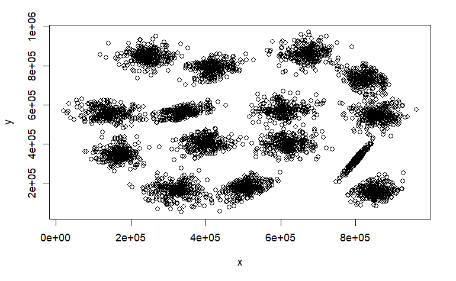

```r
plot(d1)
```

### Part 2.2-B-ii

Here in the graph we can see the 15 clusters above. We can see each cluster having dense points and the all clusters looks individually and the points within cluster are close to each other.

### Part 2.2-C-i

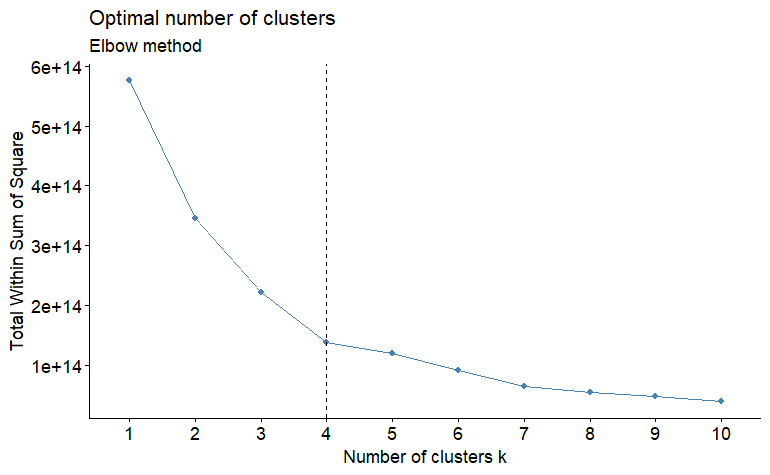

```r
library(NbClust)
fviz_nbclust(d1, kmeans, method = "wss") +
    geom_vline(xintercept = 4, linetype = 2)+
  labs(subtitle = "Elbow method")
```

### Part 2.2-C-ii

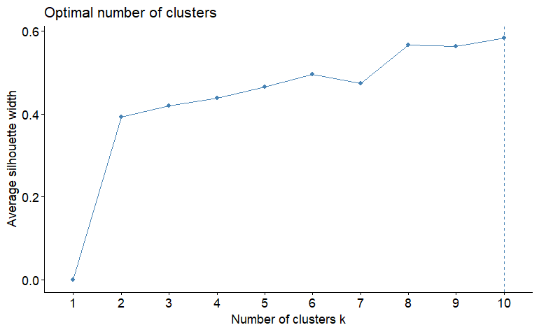

```r
fviz_nbclust(d1,FUNcluster=kmeans,method = "silhouette")
```

### Part 2.2-C-iii

```r
cat("The Number of clusters when we are using k-means is 10 on this data")
```

```
The Number of clusters when we are using k-means is 10 on this data
```

### Part 2.2-D-i

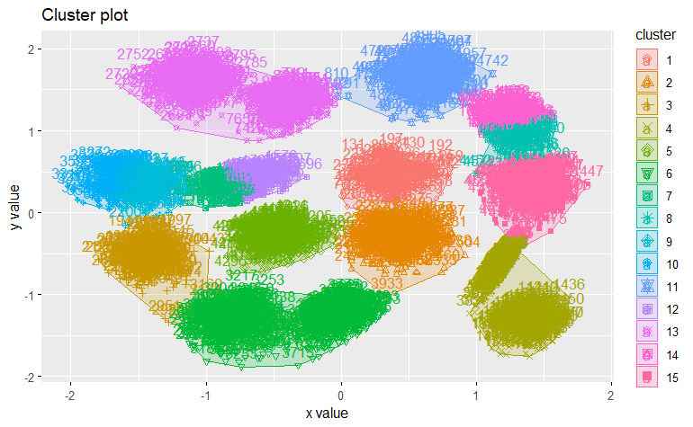

```r
kmeans_r <- kmeans(data1, centers = 15)
fviz_cluster(kmeans_r, d1)
```

### Part 2.2-d-ii

Here we can see that it didnt perform the clustering properly, some clusters are joined together into one cluster, this we cannot see proper clusters, many nearby clusters are joined.

### Part 2.2-E-i

By doing experiments, i get to know that MinPts=8, If i take other value then some times i am getting joined clusters, and i am getting many individual clusters. If we take 1 as MinPts then every point will have centroid. so we have to take atleast MinPts as 3. in our data we didnt see many outlairs so no need to keep the MinPts as high so i choose MinPts as 8.